# RRproject-original

Hanwenmiao436819

2024-06-08

# The original project’s URL is: https://www.kaggle.com/code/artemburenok/stock-analysis-monte-carlo-build-portfolio

# Author: ARTEM BURENOK

#### Purpose of Analysis:

# - Build moving averages of various stocks

# - Determine correlations between stock returns

# - Create an optimal portfolio

# - Try to predict the future behavior of the stocks

### Code Reproduction Explanation

# I have converted the original project’s Python code to R code. Due to Twitter’s delisting,

# there is no stock price information for Twitter on Yahoo Finance.

# Therefore, the new investment portfolio consists of three companies,

# which may slightly affect the results.

```r
# Setting working path
setwd("C:/Users/lulut/Desktop/RRproject436819")
today <- as.Date("2022-02-23")
year_ago <- as.Date(today - 365)
# Three company for data extraction
company_list <- c("TSLA", "MSFT", "AMZN")

library(quantmod)
for (company in company_list) {
  assign(company, getSymbols(company, src = 'yahoo', from = year_ago, to = today, auto.assign = FALSE))
}
save.image(file = "Data.RData")
library(dplyr)
library(corrplot)
library(ggplot2)
library(GGally)
library(xts)
library(MASS)
library(gridExtra)
```

```r
rm(list = ls())
load("Data.RData")

for(i in 1:20){
  print(head(eval(parse(text =company_list[i])), 5))
}
```

```
           TSLA.Open TSLA.High TSLA.Low TSLA.Close TSLA.Volume TSLA.Adjusted
2021-02-23  220.7100  237.8700 206.3333   232.9467   199820700      232.9467
2021-02-24  237.2833  248.3333 231.3900   247.3400   110301000      247.3400
2021-02-25  242.0500  245.7367 223.5267   227.4067   117071700      227.4067
2021-02-26  233.3333  235.5667 219.8367   225.1667   123267600      225.1667
2021-03-01  230.0367  239.6667 228.3500   239.4767    81408600      239.4767
           MSFT.Open MSFT.High MSFT.Low MSFT.Close MSFT.Volume MSFT.Adjusted
2021-02-23    230.33    234.83   228.73     233.27    30228700      226.8629
2021-02-24    230.01    235.20   229.00     234.55    26339700      228.1077
2021-02-25    232.08    234.59   227.88     228.99    39542200      222.7004
2021-02-26    231.53    235.37   229.54     232.38    37819200      225.9973
2021-03-01    235.90    237.47   233.15     236.94    25324000      230.4321
           AMZN.Open AMZN.High AMZN.Low AMZN.Close AMZN.Volume AMZN.Adjusted
2021-02-23  156.3515  160.2365 154.6800   159.7250    93544000      159.7250
2021-02-24  158.3375  158.5615 156.2690   157.9765    60226000      157.9765
2021-02-25  156.8370  158.9130 152.3880   152.8580    90676000      152.8580
2021-02-26  154.7600  156.1220 151.8350   154.6465    85518000      154.6465
2021-03-01  156.3945  157.4780 154.8995   157.3070    54582000      157.3070
[1] NA
[1] NA
[1] NA
[1] NA
[1] NA
[1] NA
[1] NA
[1] NA
[1] NA
[1] NA
[1] NA
[1] NA
[1] NA
[1] NA
[1] NA
[1] NA
[1] NA
```

```r
for(i in 1:3){
  temp <- eval(parse(text =company_list[i]))
  colnames(temp) = c("Open","High","Low","Close","Volume","Adjusted")
  assign(company_list[i],temp)
}
rm(temp)
```

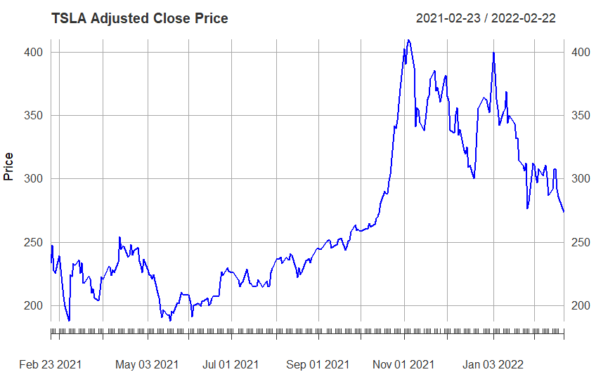

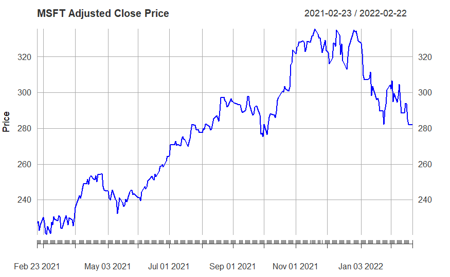

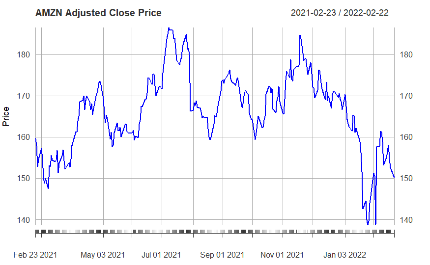

```r
for(i in 1:length(company_list)){
  print(plot(eval(parse(text =company_list[i]))$Adjusted, main = paste0(company_list[i]," Adjusted Close Price"), ylab = "Price", xlab = "Date", type = "l", col = "blue"))
}
```

##Moving average¶ Moving average - function whose value at each point is equal to some average value of the original function for the previous period.

Formula for calculations:

SUM = sum of prices for past x days; MA = SUM / x

```r
MA_days <- c(10, 20, 30)

for(i in 1:3){
  temp = eval(parse(text =company_list[i]))
  temp$`MA10` <- rollmean(temp$Adjusted, k = 10, fill = NA,align = "right")
  temp$`MA20` <- rollmean(temp$Adjusted, k = 20, fill = NA,align = "right")
  temp$`MA30` <- rollmean(temp$Adjusted, k = 30, fill = NA,align = "right")
  assign(company_list[i],temp)
}
rm(temp)

for(i in 1:20){
  print(head(eval(parse(text =company_list[i])), 5))
}
```

```
               Open     High      Low    Close    Volume Adjusted MA10 MA20 MA30
2021-02-23 220.7100 237.8700 206.3333 232.9467 199820700 232.9467   NA   NA   NA
2021-02-24 237.2833 248.3333 231.3900 247.3400 110301000 247.3400   NA   NA   NA
2021-02-25 242.0500 245.7367 223.5267 227.4067 117071700 227.4067   NA   NA   NA
2021-02-26 233.3333 235.5667 219.8367 225.1667 123267600 225.1667   NA   NA   NA
2021-03-01 230.0367 239.6667 228.3500 239.4767  81408600 239.4767   NA   NA   NA
             Open   High    Low  Close   Volume Adjusted MA10 MA20 MA30
2021-02-23 230.33 234.83 228.73 233.27 30228700 226.8629   NA   NA   NA
2021-02-24 230.01 235.20 229.00 234.55 26339700 228.1077   NA   NA   NA
2021-02-25 232.08 234.59 227.88 228.99 39542200 222.7004   NA   NA   NA
2021-02-26 231.53 235.37 229.54 232.38 37819200 225.9973   NA   NA   NA
2021-03-01 235.90 237.47 233.15 236.94 25324000 230.4321   NA   NA   NA
               Open     High      Low    Close   Volume Adjusted MA10 MA20 MA30
2021-02-23 156.3515 160.2365 154.6800 159.7250 93544000 159.7250   NA   NA   NA
2021-02-24 158.3375 158.5615 156.2690 157.9765 60226000 157.9765   NA   NA   NA
2021-02-25 156.8370 158.9130 152.3880 152.8580 90676000 152.8580   NA   NA   NA
2021-02-26 154.7600 156.1220 151.8350 154.6465 85518000 154.6465   NA   NA   NA
2021-03-01 156.3945 157.4780 154.8995 157.3070 54582000 157.3070   NA   NA   NA
[1] NA
[1] NA
[1] NA
[1] NA
[1] NA
[1] NA
[1] NA
[1] NA
[1] NA
[1] NA
[1] NA
[1] NA
[1] NA
[1] NA
[1] NA
[1] NA
[1] NA
```

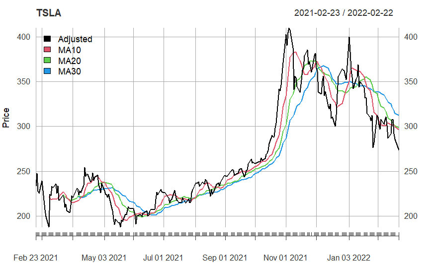

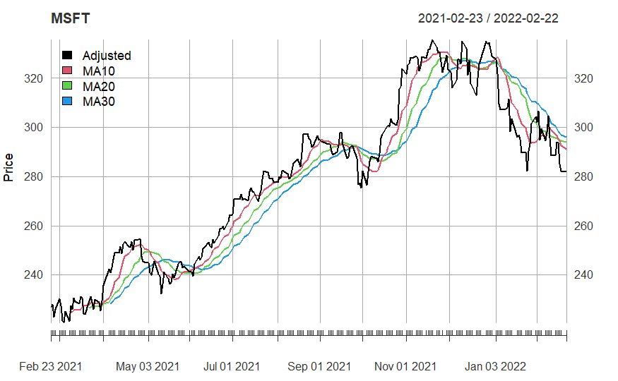

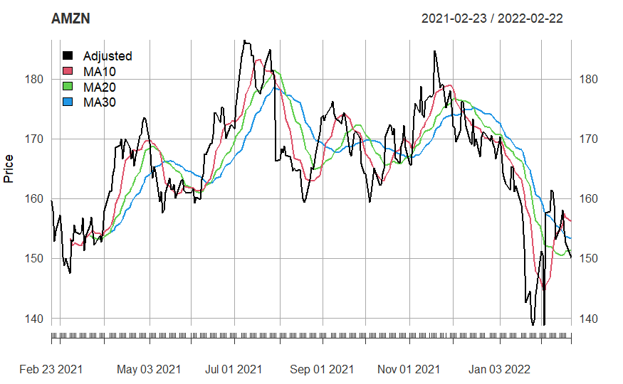

```r
plot_graphic <- function(company, company_string) {
  plot(company[,6:9], type = "l", xlab = "Date", ylab = "Price", main = company_string,col = 1:4,legend.loc = "topleft")
}



for (i in 1:length(company_list)) {
  print(plot_graphic(eval(parse(text =company_list[i])), company_list[i]))
}
```

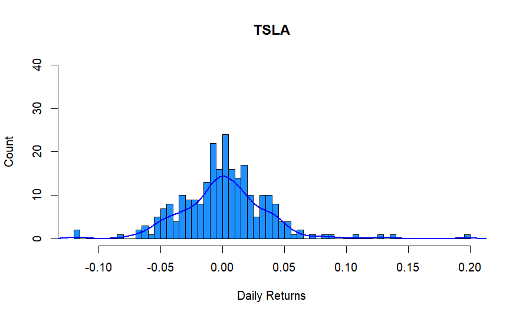

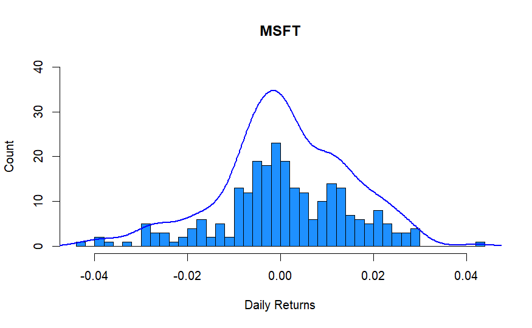

```r
for (i in 1:length(company_list)){
  temp = eval(parse(text =company_list[i]))
  temp$`Daily Returns` <- diff(temp$Adjusted)/stats::lag(temp$Adjusted, k = 1)
  assign(company_list[i],temp)
  hist(na.omit(temp$`Daily Returns`), breaks=50, col='dodgerblue', main=company_list[i], xlab='Daily Returns', ylab='Count',ylim = c(0,40))
  lines(density(na.omit(temp$`Daily Returns`)),col = "blue",lwd = 2)
}
```

[figure not shown]

```r
NA
```

```r
# Create dataframe with stock returns

stock_returns <- list()
for(i in 1:3){
  stock_returns[[i]] <- eval(parse(text =company_list[i]))$`Daily Returns`
}
stock_returns <- do.call(cbind,stock_returns)
colnames(stock_returns) <- company_list
head(stock_returns)
```

```
                   TSLA         MSFT        AMZN
2021-02-23           NA           NA          NA
2021-02-24  0.061788073  0.005487068 -0.01094697
2021-02-25 -0.080590825 -0.023704843 -0.03240039
2021-02-26 -0.009850152  0.014804011  0.01170039
2021-03-01  0.063552911  0.019623037  0.01720380
2021-03-02 -0.044527636 -0.012956777 -0.01640426
```

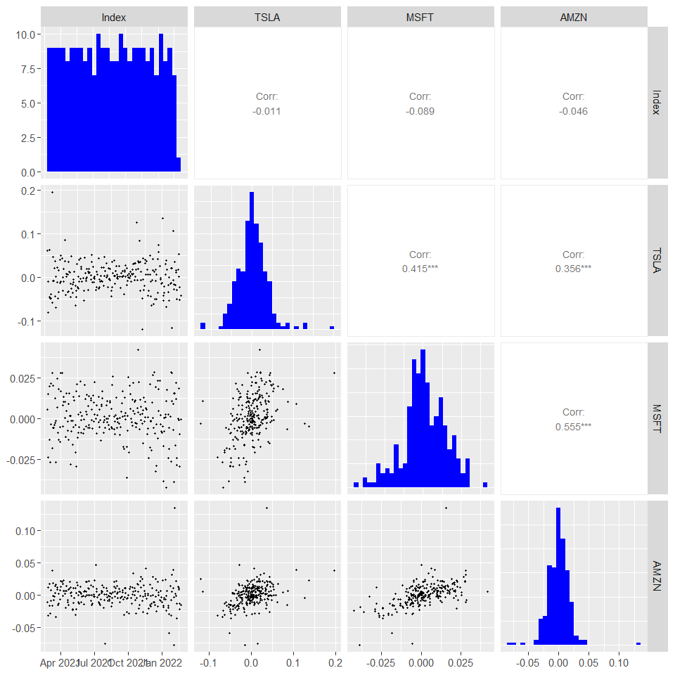

```r
# Plot pairplot
stock_returns <- na.omit(stock_returns)
ggpairs(stock_returns,
        upper = list(continuous = wrap("cor", size = 3)),
        lower = list(continuous = wrap("points", size = 0.5)),
        diag = list(continuous = wrap("barDiag", bins = 30, fill = "blue")))
```

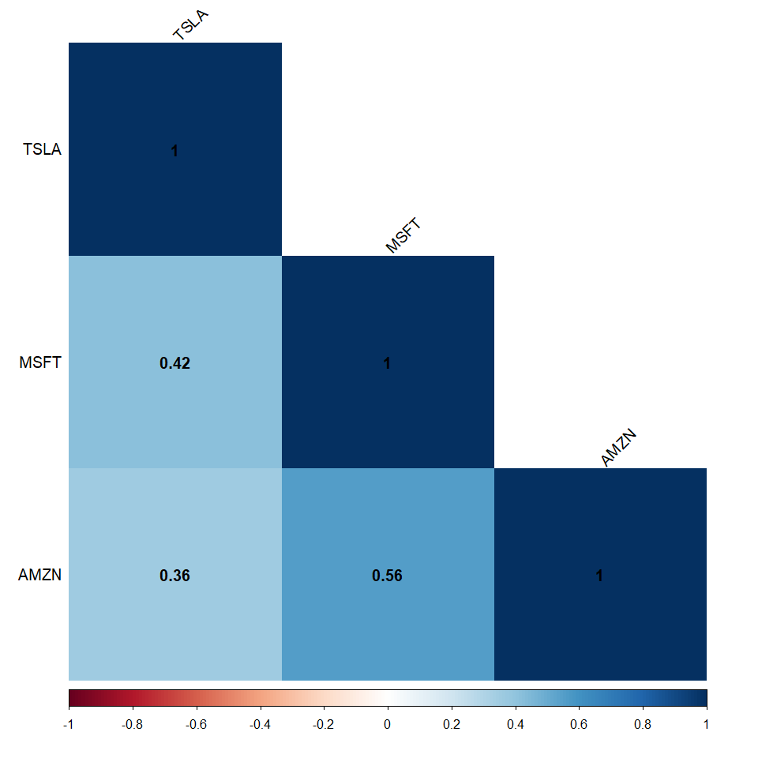

```r
# Calculate the correlation matrix
corr = cor(stock_returns,use = "complete.obs")

# Create the correlogram
corrplot(corr, type = "lower",
         method = "shade",
         addCoef.col = "black",
         tl.col = "black", tl.srt = 45)
```

## Amazon and Microsoft have the most correlated daily profits

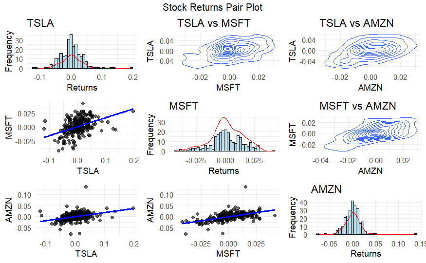

```r
# Function to create plots
create_plot <- function(data, x_label, y_label) {
  ggplot(data = data, aes(x = x, y = y)) +
    geom_point(alpha = 0.6) +
    geom_smooth(method = "lm", se = FALSE, color = "blue") +
    labs(x = x_label, y = y_label) +
    theme_minimal()
}

# Create plots
k <- 3
plots <- list()
stock_return <- as.data.frame(na.omit(stock_returns))

# Loop through each combination of stocks
for (i in 1:k) {
  for (j in 1:k) {
    # Plot histogram and density on diagonal
    if (i == j) {
      data <- data.frame(returns = stock_return[, i])
      plots[[length(plots) + 1]] <- ggplot(data, aes(x = returns)) +
        geom_histogram(bins = 40, fill = "lightblue", color = "black") +
        geom_density(alpha = 0.5, color = "red") +
        labs(title = colnames(stock_return)[i], x = "Returns", y = "Frequency") +
        theme_minimal()
    }
    # Plot scatter plot with regression line on lower triangle
    if (i > j) {
      data <- data.frame(x = stock_return[, j], y = stock_return[, i])
      plots[[length(plots) + 1]] <- create_plot(data, colnames(stock_return)[j], colnames(stock_returns)[i])
    }
    # Plot contour plot on upper triangle
    if (i < j) {
      data <- data.frame(x = stock_return[, j], y = stock_return[, i])
      plots[[length(plots) + 1]] <- ggplot(data, aes(x = x, y = y)) +
        geom_density_2d() +
        labs(title = paste(colnames(stock_returns)[i], "vs", colnames(stock_returns)[j]), x = colnames(stock_returns)[j], y = colnames(stock_returns)[i]) +
        theme_minimal()
    }
  }
}

# Arrange plots in a grid with larger plots
grid.arrange(grobs = plots, ncol = k, nrow = k, top = "Stock Returns Pair Plot")
```

#The expected return of the portfolio is the total expected return of the securities included in it, weighted taking into account their share in the portfolio.

```r
# Calculate mean income for each stock
stock_returns <- na.omit(stock_returns)
mean_income <- apply(stock_returns, 2, mean)

# Calculate covariance matrix of returns
cov_returns <- cov(stock_returns)

# Number of stocks
count <- ncol(stock_returns)

# Print mean income and covariance matrix
print(mean_income)
```

```
         TSLA          MSFT          AMZN
 1.284862e-03  9.632781e-04 -7.186122e-05
```

```r
print(cov_returns)
```

```
             TSLA         MSFT         AMZN
TSLA 0.0013101062 0.0002108591 0.0002408757
MSFT 0.0002108591 0.0001967818 0.0001454028
AMZN 0.0002408757 0.0001454028 0.0003487361
```

```r
# Function to generate random portfolio
randomPortfolio <- function(input) {
  set.seed(input)
  share <- exp(rnorm(count))
  share <- share / sum(share)
  return(share)
}

# Function to calculate portfolio income
IncomePortfolio <- function(Rand) {
  return(sum(mean_income * Rand))
}

# Function to calculate portfolio risk
RiskPortfolio <- function(Rand) {
  return(sqrt(t(Rand) %*% cov_returns %*% Rand))
}

combinations <- 4000
risk <- rep(0, combinations)
income <- rep(0, combinations)
portfolio <- matrix(0, nrow = combinations, ncol = count)

# Loop to create new combinations of shares
for (i in 1:combinations) {
  rand <- randomPortfolio(i)
  portfolio[i, ] <- rand
  risk[i] <- RiskPortfolio(rand)
  income[i] <- IncomePortfolio(rand)
}
```

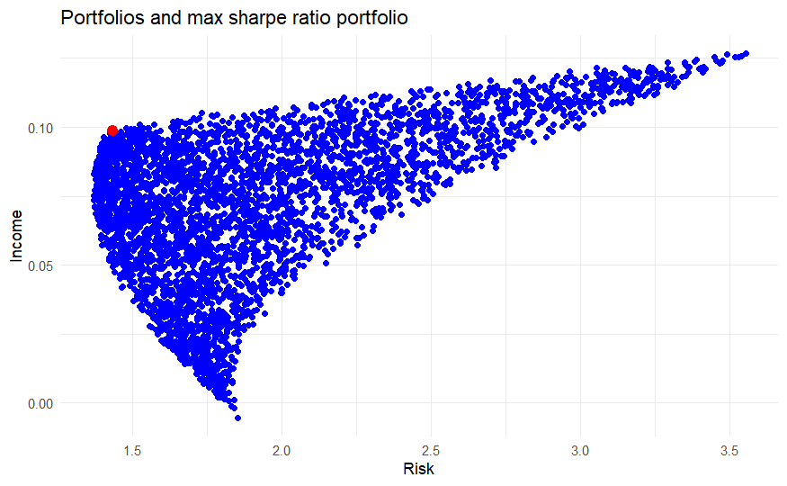

```r
# Convert numpy arrays to R vectors/matrices
risk <- risk * 100
income <- income * 100

# Find index of maximum Sharpe ratio
MaxSharpRatio <- which.max(income / risk)

# Create scatter plot
scatter_plot <- ggplot() +
  geom_point(data = data.frame(Risk = risk, Income = income), aes(x = Risk, y = Income), color = "blue", shape = 16) +
  geom_point(data = data.frame(Risk = risk[MaxSharpRatio], Income = income[MaxSharpRatio]), aes(x = Risk, y = Income), color = "red", shape = 19, size = 3) +
  labs(x = "Risk", y = "Income", title = "Portfolios and max sharpe ratio portfolio") +
  theme_minimal()

# Show the plot
print(scatter_plot)
```

```r
best_port <- portfolio[MaxSharpRatio,]
for (i in 1:length(company_list)) {
  print(paste(company_list[i], ": ", best_port[i]))
}
```

```
[1] "TSLA :  0.0802861841294354"
[1] "MSFT :  0.916232781825089"
[1] "AMZN :  0.00348103404547584"
```

##Due to the absence of one stock, the weights are different. However, looking at the results, heavily investing in Microsoft from 2021 to 2022 was the right move. Although Tesla didn’t perform well in 2022, its stock rose by 90% in 2023 !

##Try to predict price behavior with method Monte Carlo

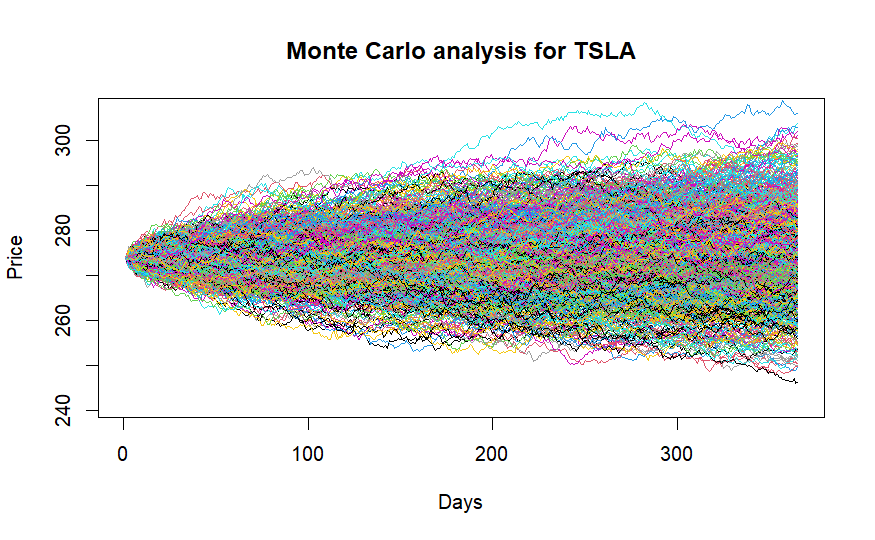

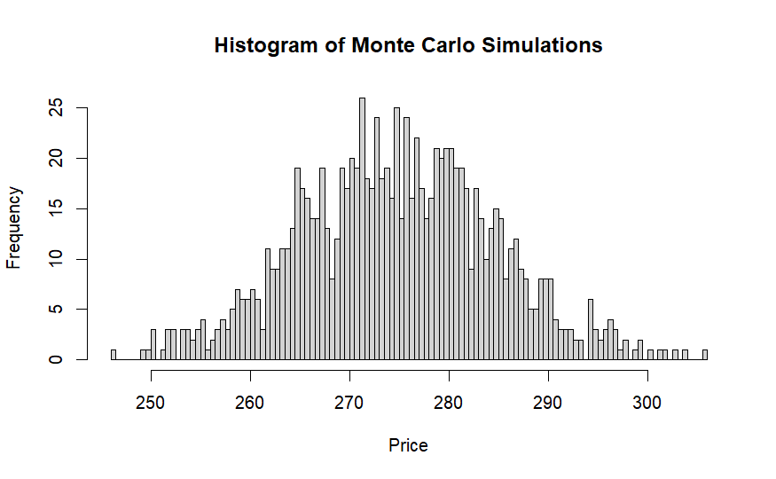

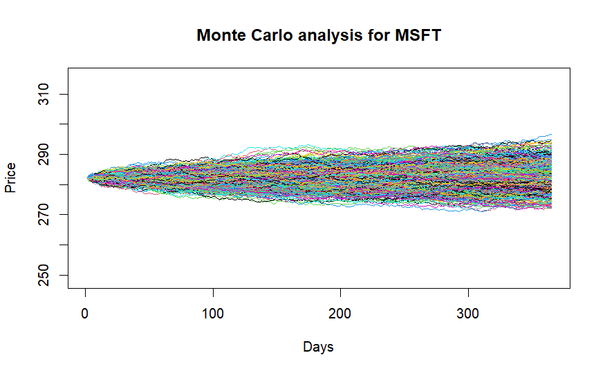

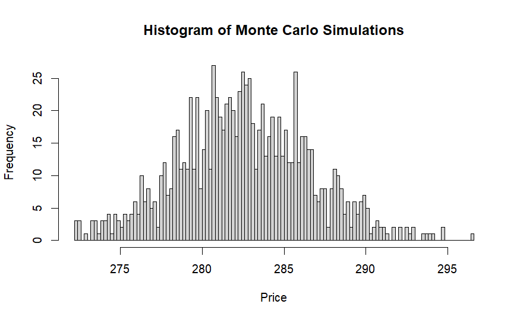

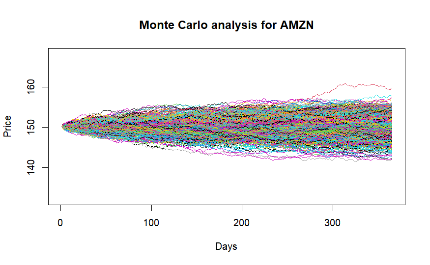

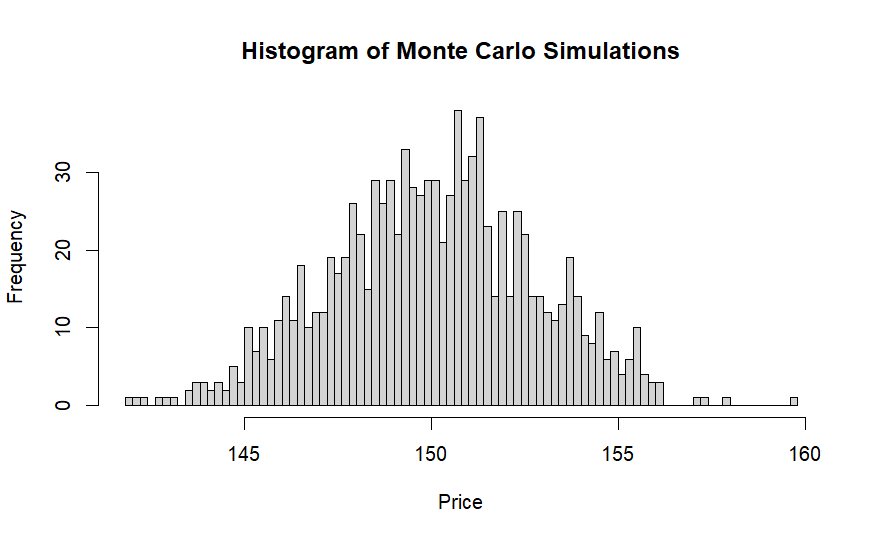

```r
days <- 365
dt <- 1 / days

mu <- apply(stock_returns, 2, mean)
sigma <- apply(stock_returns, 2, sd)

monte_carlo <- function(start_price, days, mu, sigma) {
  price <- rep(0, days)
  price[1] <- start_price

  shock <- rep(0, days)
  drift <- rep(0, days)

  for (x in 2:days) {
    shock[x] <- rnorm(1, mean = mu * dt, sd = sigma * sqrt(dt))
    drift[x] <- mu * dt

    price[x] <- price[x - 1] + (price[x - 1] * (drift[x] + shock[x]))
  }

  return(price)
}

sim <- rep(0, 1000)


for(j in 1:3){
  start_price <- tail(eval(parse(text =company_list[j]))$Adjusted,1)
  result <- monte_carlo(start_price, days, mu[company_list[j]], sigma[company_list[j]])
  sim[1] <- result[days]
  plot(result, type = "l", xlab = "Days", ylab = "Price", col = 1,main = paste0("Monte Carlo analysis for ", company_list[j]),ylim = c(0.88*start_price,1.12*start_price))
  for (i in 2:1000) {
  result <- monte_carlo(start_price, days, mu[company_list[j]], sigma[company_list[j]])
  sim[i] <- result[days]
  lines(result, col = i)
  }
  hist(sim, breaks = 100, main = "Histogram of Monte Carlo Simulations", xlab = "Price")
  text(0.6, 0.7, paste("Mean: ", mean(sim), "\nStd: ", sd(sim), "\nStart Price: ", start_price))
}
```

```r
NA
NA
```